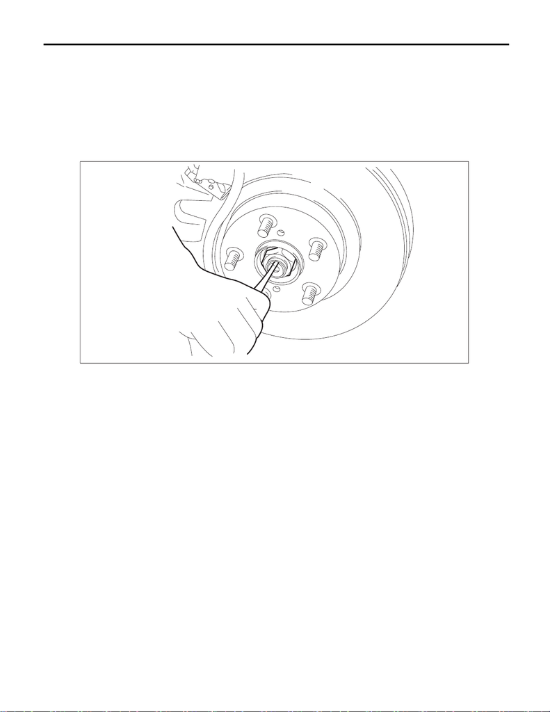

DS-18

Front Axle

DRIVE SHAFT SYSTEM

3. Front Axle

A: REMOVAL

1) Lift up the vehicle, and then remove the front wheels.

2) Remove the nut - axle.

CAUTION:

Do not loosen the nut - axle while the front axle is loaded. Doing so may damage the hub unit COMPL.

(1) Lift the crimped section of the nut - axle.

(2) Remove the nut - axle using a socket wrench while depressing the brake pedal.

3) Remove the disc brake assembly. <Ref. to BR-25, REMOVAL, Front Disc Brake Assembly.>

4) Remove the disc rotor. <Ref. to BR-22, REMOVAL, Front Disc Rotor.>

DS-00486

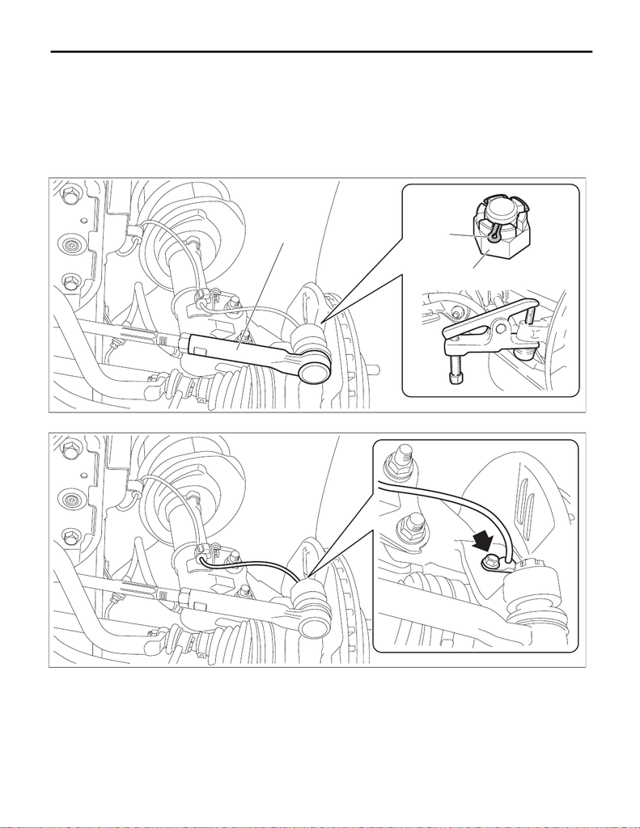

DS-19

Front Axle

DRIVE SHAFT SYSTEM

5) Disconnect the tie-rod end.

(1) Pull out the cotter pin (a).

(2) Remove the castle nut (b).

(3) Using a tie-rod ball joint puller, remove the tie-rod end (c).

CAUTION:

Be careful not to damage the boot of the joint.

Preparation tool:

Tie-rod ball joint puller

6) Remove the bolts, and remove the front ABS wheel speed sensor.

FS-00505

(a)

(b)

(c)

DS-00604

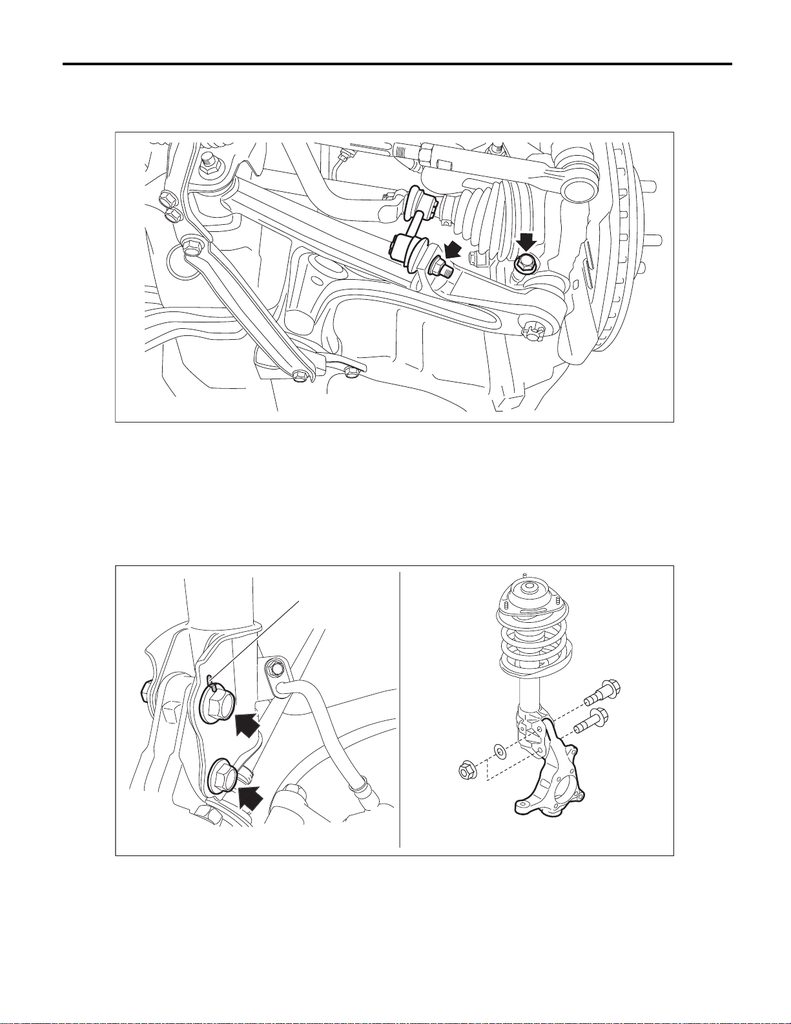

DS-20

Front Axle

DRIVE SHAFT SYSTEM

7) Remove the stabilizer link and ball joint.

CAUTION:

Be careful not to damage the boot of the joint.

8) Remove the front drive shaft. <Ref. to DS-48, REMOVAL, Front Drive Shaft.>

9) Remove the housing assembly - front axle.

CAUTION:

• Be careful of the weight of the housing assembly - front axle.

• Be careful not to damage the spline portion of the drive shaft.

(1) Place an alignment mark (a) on the adjusting bolt and the strut assembly.

(2) Remove the adjusting bolts and flange bolts for the strut assembly, and then remove the housing as-

sembly - front axle.

NOTE:

10) For removal of the hub unit COMPL - front axle, refer to “Front Hub Unit Bearing”. <Ref. to DS-25, RE-

MOVAL, Front Hub Unit Bearing.>

DS-00583

DS-00606

(a)

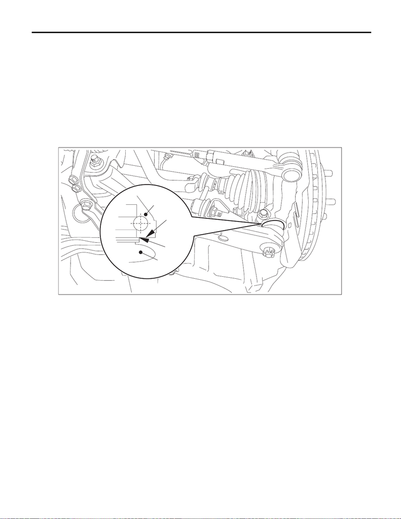

DS-21

Front Axle

DRIVE SHAFT SYSTEM

B: INSTALLATION

1) Install the housing assembly - front axle to the strut assembly.

(1) Align alignment marks on the camber adjusting bolt and strut.

(2) While holding the bolt head of adjusting bolt, tighten the nut.

Tightening torque:

155 N·m (15.8 kgf-m, 114.3 ft-lb)

2) Install the front drive shaft assembly. <Ref. to DS-49, INSTALLATION, Front Drive Shaft.>

3) Install the ball joint assembly.

CAUTION:

• Before tightening, make sure the bottom surface of the housing assembly - front axle and the

stepped section of ball joint are in contact.

• Be careful not to damage the boot of the joint.

Tightening torque:

50 N·m (5.1 kgf-m, 36.9 ft-lb)

4) Install the front ABS wheel speed sensor.

Tightening torque:

7.5 N·m (0.8 kgf-m, 5.5 ft-lb)

5) Install the disc rotor.

6) Install the disc brake assembly.

Tightening torque:

STI model: 155 N·m (15.8 kgf-m, 114.3 ft-lb)

Except for STI model: 80 N·m (8.2 kgf-m, 59.0 ft-lb)

7) Install the brake hose bracket.

Tightening torque:

33 N·m (3.4 kgf-m, 24.3 ft-lb)

8) Install the stabilizer link assembly.

Tightening torque:

60 N·m (6.1 kgf-m, 44.3 ft-lb)

(a) Bottom surface of housing ASSY -

front axle

(c) Housing ASSY - front axle (d) Ball joint ASSY

(b) Raised section of ball joint

FS-00508

(a)

(b)

(c)

(d)

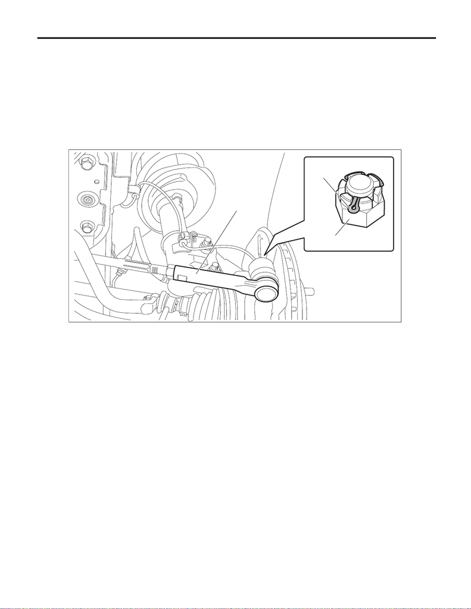

DS-22

Front Axle

DRIVE SHAFT SYSTEM

9) Connect the tie-rod ends.

(1) Connect the tie-rod ends to the housing assembly - front axle.

(2) Tighten the castle nuts to the specified torque.

CAUTION:

When connecting the tie-rod, do not hit the cap at bottom of tie-rod end with a hammer.

Tightening torque:

27 N·m (2.8 kgf-m, 19.9 ft-lb)

(3) Tighten the castle nut within the range of 60° so that the cotter pin hole and cutout portion of the castle

nut are aligned.

(4) Insert the cotter pin, and bend the tip of the pin to fix it.

10) While depressing the brake pedal, tighten the nut - axle to the specified torque.

CAUTION:

Do not load the front axle before tightening the nut - axle. Doing so may damage the hub unit COMPL.

Tightening torque:

220 N·m (22.4 kgf-m, 162.3 ft-lb)

(a) Tie-rod end (b) Castle nut (c) Cotter pin

DS-00581

(a)

(c)

(b)

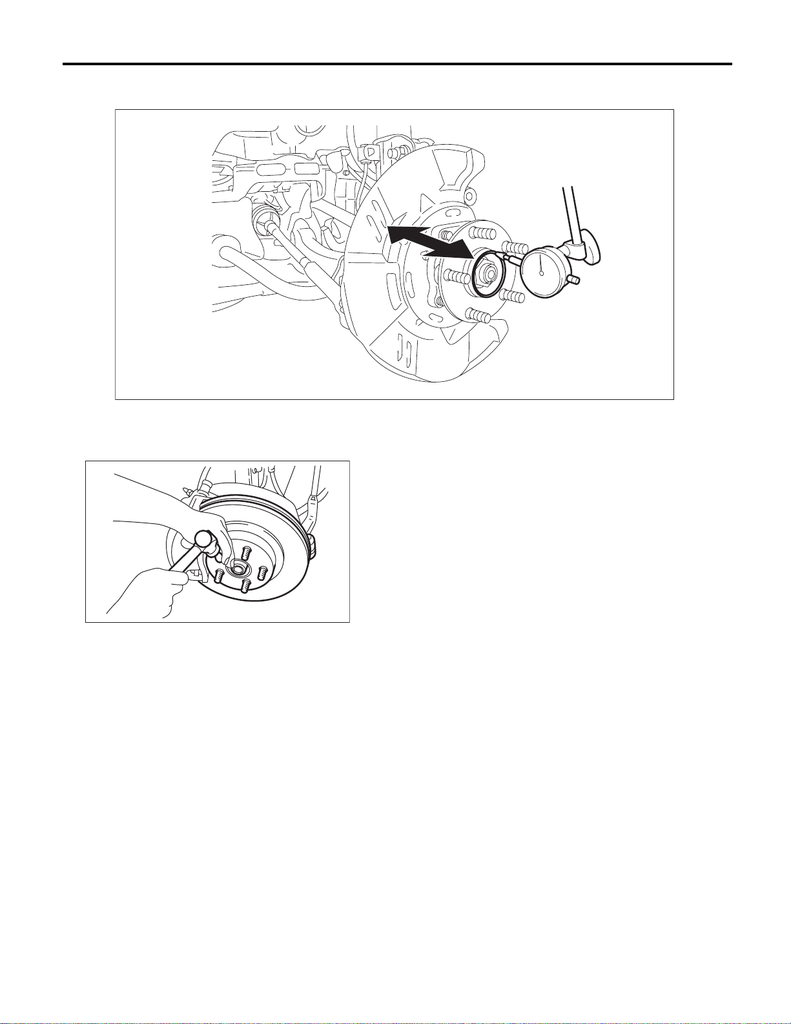

DS-23

Front Axle

DRIVE SHAFT SYSTEM

11) Inspect the lean of axis direction using a dial gauge. Replace the hub unit COMPL - front axle if the play

exceeds the limit.

Service limit:

Maximum: 0.05 mm (0.0020 in)

12) After tightening the nut - axle, lock it securely.

DS-00493

DS-00048

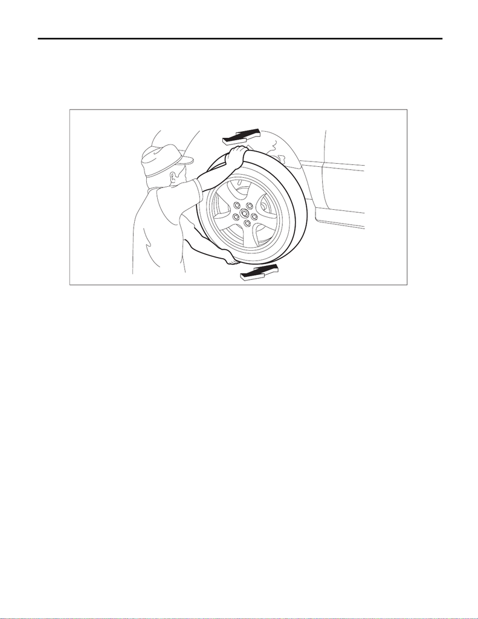

DS-24

Front Axle

DRIVE SHAFT SYSTEM

13) Install the front wheels, and perform the following inspections.

Tightening torque:

120 N·m (12.2 kgf-m, 88.5 ft-lb)

1. Check the wheels for smooth rotation.

2. Check that there is no play by moving the upper and lower portions of front tire in an axial direction with

the brake pedal released.

• Play exists → Check the hub unit COMPL - front axle. <Ref. to DS-31, INSPECTION, Front Hub Unit

Bearing.>

3. Check that there is no play by moving the upper and lower portions of front tire in an axial direction with

the brake pedal depressed.

• Play exists → Replace the ball joint assembly. <Ref. to FS-33, REMOVAL, Front Ball Joint.>

14) Inspect the wheel alignment and adjust if necessary.

• Inspection: <Ref. to FS-10, INSPECTION, Wheel Alignment.>

• Adjustment: <Ref. to FS-15, ADJUSTMENT, Wheel Alignment.>

CAUTION:

When the wheel alignment has been adjusted, perform “VDC sensor midpoint setting mode”. <Ref.

to VDC-16, ADJUSTMENT, VDC Control Module and Hydraulic Control Unit (VDCCM&H/U).>

15) Perform reinitialization of the auto headlight beam leveler system. (Model with auto headlight beam lev-

eler) <Ref. to LI-16, PROCEDURE, Auto Headlight Beam Leveler System.>

FS-00510